# Weimann et al. 2022 Reply

Chauncey Gadek

30 September, 2022

This markdown file is meant to illustrate workflow (at a high level) for our reanalysis of Wiemann et al. (2022). Broadly, we correct a single erroneous calibration point and re analyse the data following their presumed workflow. We then use Bayesian logistic regression to appropriately interrogate their data for a metabolic signal.

# Apply Prediction Interval to original data

## Linear model of original data as in Figure 1d.

```
##
## Call:
## lm(formula = Log.10..Upper.MR ~ Log.10..Body.Mass..g., data = dat.lm)
##
## Residuals:
##     Min      1Q  Median      3Q     Max
## -3.3108 -0.0774  0.1558  0.2458  0.5896
##
## Coefficients:
##                       Estimate Std. Error t value Pr(>|t|)
## (Intercept)            0.44194    0.18225   2.425   0.0188 *
## Log.10..Body.Mass..g.  1.01087    0.04317  23.416   <2e-16 ***
## ---
## Signif. codes:  0 '***' 0.001 '**' 0.01 '*' 0.05 '.' 0.1 ' ' 1
##
## Residual standard error: 0.5601 on 53 degrees of freedom
## Multiple R-squared:  0.9119, Adjusted R-squared:  0.9102
## F-statistic: 548.3 on 1 and 53 DF,  p-value: < 2.2e-16
```

First re-running a simple linear model with the data presented in Wiemann et al. (2022) figure 1d, we see a log-log relationship between body size and their lipoxidation signature-derived metabolic rate has a slope of ~ 1. This is unexpected given the body of research on metabolic rate body size scaling coefficients.

Wiemann et al. (2022) used a 95% confidence interval to “predict” unknown thermal regimes from their lipoxidation signature-derived metabolic rates. But confidence intervals are inappropriate for predicting unknown values. Prediction intervals are a more appropriate classification tool–relating directly to a model’s ability to predict new data. We generate prediction intervals for known endotherms and known other (thermy) based on the unaltered Wiemann et al. (2022) data. It is important to understand the overlap between prediction intervals parameterized from known data in order to evaluate the predictive power of Wiemann et al. (2022) framework.

This next code chunk does some data wrangling and generates prediction intervals based on the original Wiemann et al. (2022) data.

```r
#annoying but I want masses and names to match in each dataframe. The data from Weimann et al. do not match exactly by taxon name.
calib.masses <- dat.lm%>%
  dplyr::select(Taxon, Log.10..Body.Mass..g., Body.mass..g., classification)%>%
  filter(Taxon %in% dat.calib$Taxon)

calib.extant.masses <- dat.lm%>%
  dplyr::select(Taxon, Log.10..Body.Mass..g., Body.mass..g., classification)%>%
  filter(Taxon %in% dat.calib.extant$Taxon.Name)

dat.calib <-left_join(dat.calib, calib.masses)

dat.calib.extant<- dat.calib.extant%>%
  mutate(Taxon = Taxon.Name)%>%
left_join(., calib.extant.masses, by="Taxon")%>%
  mutate(Log10.Lit.Mass.Specific.MR = log10(Literature.MR..mL.O2...1.h...1.g. * Body.mass..g.))

#Prediction intervals

#Full dataset
orig_df_full <- predict(lm.m.mr, interval="prediction")%>%cbind(dat.lm, .)

#Endotherms
orig_df_endo <- dat.lm%>%
  filter(classification=="endo",
         Age =="Extant")%>%
  lm(Log.10..Upper.MR ~Log.10..Body.Mass..g., data=.)%>%
  predict(., interval="prediction")%>%
  cbind(dat.lm%>%filter(classification=="endo",
         Age =="Extant"), .)

# Non-endotherms
orig_df_oth <- dat.lm%>%
  filter(classification %in% c("ecto", "meso","oth"),
         Age =="Extant")%>%
  lm(Log.10..Upper.MR ~Log.10..Body.Mass..g., data=.)%>%
  predict(., interval="prediction")%>%
  cbind(dat.lm%>%filter(classification %in% c("ecto", "meso","oth"),
         Age =="Extant"), .)
```

## Plot prediction intervals

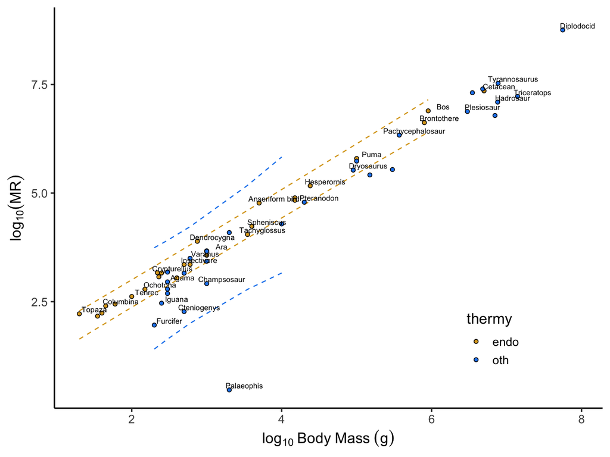

Blue points are non-endotherm samples and yellow points are endotherm samples as designated by Wiemann et al. (2022). Yellow dashed lines are upper and lower bounds of prediction interval for known endotherm only linear model. Blue dashed lines delineate prediction interval for known other points. Note the prediction interval for non-endotherms encompasses 100% of known endotherm data points (if extrapolated).

## Expected Scaling relationship

Metabolic rate literature has shown that metabolic rate scales with mass to the power of (-1/4). Therefore log-log plots of MR against mass show a negative slope of ~ -1/4. Is this present in Wiemann et al. (2022) literature-derived MR and mass data? Given the poor documentation of sources for literature MR, the disparate types of MR used in this analysis (BMR, FMR, etc…) do their data show this expected trend? To examine this, we classified extant taxa from Wiemann et al. (2022) as known endotherms or ectotherms and plotted their mass-specific MR derived from the literature (but inadequately cited in Wiemann et al. (2022) ) against their body masses in a log-log plot.

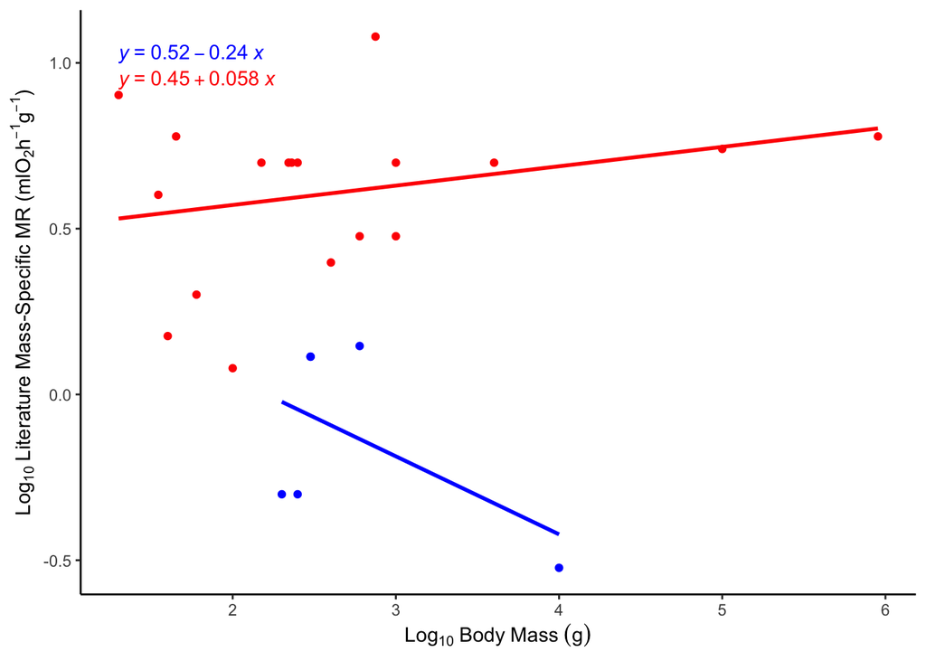

We see that known endotherms in red show a slightly positive slope barely greater than zero–running counter to the expected -1/4 slope derived from previous work. Ecotherms actually do show an almost -1/4 slope but the association is driven by a single point, making inference dubious.

# Calibration issues

The value of 11 for the Anseriform duck which drives the Wiemann et al. (2022) fossil calibration (Figure 1B) is from Legendre et al. (2016) by way of Montes et al. (2007) where they measured RMR in captive *Anas platyrynchos* ducklings in *mL* O<sub>2</sub> * h<sup>-1</sup> * g<sup>-1</sup> in Montes et al. (2007) and used an allometric correction in Legendre et al. (2016) *mL* O<sub>2</sub> * h<sup>-1</sup> * g<sup>-0.67</sup> for the same values. Wiemann et al. (2022) use the allometrically corrected duck value with an uncorrected axis and possibly uncorrected values for other taxa, inflating the positive relationship between Literature MR and Amide derived values.

Therefore the value in Figure 1b for the Anseriform duck reads 11 but it should in fact be 2.35 based on calculation from the original source Montes et al. (2007).

Here are two linear models. The first is the model they used for fossil calibration in Wiemann et al. (2022). The second is the model with a corrected value for the Duck point.

```r
dat.calib[9,"Taxon"]<- dat.calib[8,1]
dat.calib[9,2]<- dat.calib[8,2]
dat.calib[9,3]<- 2.35

lm.calib <-dat.calib%>%filter(!row_number() %in% c(9))%>%
  lm(Literature.MR..mL.O2...1.h...1.g. ~ X.S.N..Amide...MC.in.vivo, data=.)

summary(lm.calib)
```

```
##
## Call:
## lm(formula = Literature.MR..mL.O2...1.h...1.g. ~ X.S.N..Amide...MC.in.vivo,
##     data = .)
##
## Residuals:
##      Min       1Q   Median       3Q      Max
## -1.85428 -1.29912  0.08717  0.90988  2.00367
##
## Coefficients:
##                           Estimate Std. Error t value Pr(>|t|)
## (Intercept)                -3.9082     1.2911  -3.027 0.023189 *
## X.S.N..Amide...MC.in.vivo   1.3000     0.2155   6.033 0.000937 ***
## ---
## Signif. codes:  0 '***' 0.001 '**' 0.01 '*' 0.05 '.' 0.1 ' ' 1
##
## Residual standard error: 1.532 on 6 degrees of freedom
## Multiple R-squared:  0.8585, Adjusted R-squared:  0.8349
## F-statistic: 36.39 on 1 and 6 DF,  p-value: 0.0009374
```

```r
#  This is how fossils were calibrated (1.2994*Fossil Amide here)-3.9047
#with added uncertainty add 1.2 to the value calculated above
```

```r
#Now replace the erroneous point

lm.calib.rm <-dat.calib%>%filter(!row_number() %in% c(8))%>%
  lm(Literature.MR..mL.O2...1.h...1.g. ~ X.S.N..Amide...MC.in.vivo, data=.)

summary(lm.calib.rm)
```

```
##
## Call:
## lm(formula = Literature.MR..mL.O2...1.h...1.g. ~ X.S.N..Amide...MC.in.vivo,
##     data = .)
##
## Residuals:
##     Min      1Q  Median      3Q     Max
## -1.5658 -1.2722 -0.6168  0.3821  3.7131
##
## Coefficients:
##                           Estimate Std. Error t value Pr(>|t|)
## (Intercept)                 0.3371     1.6915   0.199    0.849
## X.S.N..Amide...MC.in.vivo   0.3207     0.2823   1.136    0.299
##
## Residual standard error: 2.007 on 6 degrees of freedom
## Multiple R-squared:  0.177,  Adjusted R-squared:  0.03981
## F-statistic:  1.29 on 1 and 6 DF,  p-value: 0.2993
```

We can see that the corrected point brings down the R<sup>2</sup> value and raises the *P* value as expected. So the fossil calibration formula goes from 1.2994 * ( *MC in vivo*) - 3.9047 to 0.3207 * ( *MC in vivo*) + 0.3371.

## Plot R<sup>2</sup> with/without corrected calibration

Visualize the calibration according to the supplementary data calibration tab n=8 extant amniotes and calibration with duck removed.

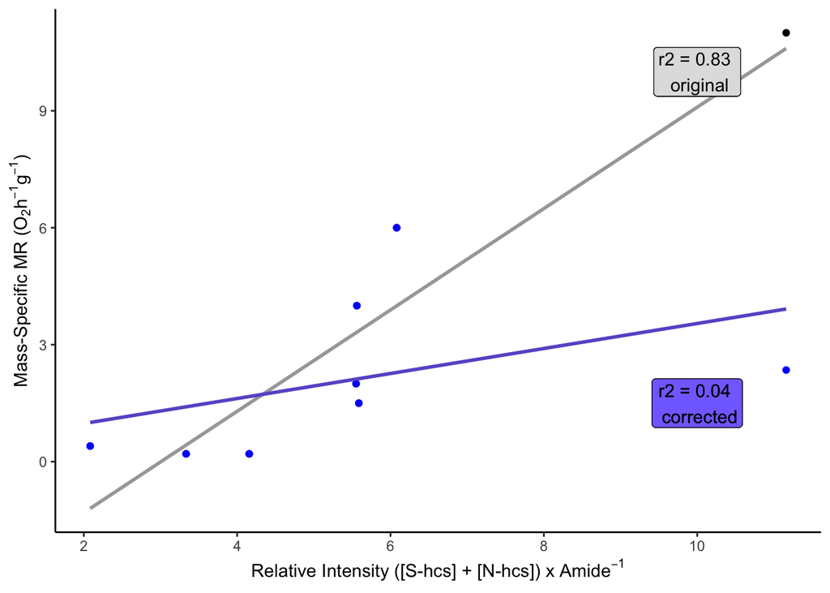

Grey line shows original calibration linear model. Purple line shows corrected linear model. The relationship all but disappears after correcting the duck point…

## Second calibration for extant taxa

Though difficult to tell from the main text, it appears there were two calibrations(?) One for fossil taxa above and one for extant taxa (See Figure S7 and ‘Extant Taxa’ tab from supplementary workbook from Wiemann et al. (2022))

They regressed n=25 literature MR values (not cited??) against spectral Amide ( *MC in vivo*) values from museum samples. We know from the literature that again this duck point ( *Dendrocygna*) cannot be correct (much higher than hummingbird). So, in absence of the known lit-derived value we will remove this point from our calibration. Second, we suspect intense phylogenetic signal within this calibration and would like to correct for it. We will use the tree that Wiemann et al. (2022) used to run a PGLS model.

```r
lm.calib.extant <-dat.calib.extant%>%
  lm(Literature.MR..mL.O2...1.h...1.g. ~ X.S.N..Amide...MC.in.vivo..normalized.spectral.intensities., data=.)

summary(lm.calib.extant)
```

```
##
## Call:
## lm(formula = Literature.MR..mL.O2...1.h...1.g. ~ X.S.N..Amide...MC.in.vivo..normalized.spectral.intensities.,
##     data = .)
##
## Residuals:
##     Min      1Q  Median      3Q     Max
## -2.9597 -0.8089  0.1948  0.9427  2.7180
##
## Coefficients:
##                                                             Estimate Std. Error
## (Intercept)                                                   -8.060      1.763
## X.S.N..Amide...MC.in.vivo..normalized.spectral.intensities.    9.527      1.393
##                                                             t value Pr(>|t|)
## (Intercept)                                                  -4.573 0.000135
## X.S.N..Amide...MC.in.vivo..normalized.spectral.intensities.   6.842 5.62e-07
##
## (Intercept)                                                 ***
## X.S.N..Amide...MC.in.vivo..normalized.spectral.intensities. ***
## ---
## Signif. codes:  0 '***' 0.001 '**' 0.01 '*' 0.05 '.' 0.1 ' ' 1
##
## Residual standard error: 1.597 on 23 degrees of freedom
## Multiple R-squared:  0.6705, Adjusted R-squared:  0.6562
## F-statistic: 46.81 on 1 and 23 DF,  p-value: 5.622e-07
```

```r
# this is where they derive the formula for calculated MR ((9.5273 * Amide) -8.0604 and then corrected MR just add 0.9

#Remove the obviously incorrect duck point

dat.calib.extant <- dat.calib.extant%>% filter(!Taxon.Name %in% c("Dendrocygna"))


lm.calib.extant.rm <-dat.calib.extant%>%
   lm(Literature.MR..mL.O2...1.h...1.g. ~ X.S.N..Amide...MC.in.vivo..normalized.spectral.intensities., data=.)
#
 summary(lm.calib.extant.rm)
```

```
##
## Call:
## lm(formula = Literature.MR..mL.O2...1.h...1.g. ~ X.S.N..Amide...MC.in.vivo..normalized.spectral.intensities.,
##     data = .)
##
## Residuals:
##     Min      1Q  Median      3Q     Max
## -2.7146 -0.9872  0.2600  1.0818  2.6010
##
## Coefficients:
##                                                             Estimate Std. Error
## (Intercept)                                                   -6.141      1.897
## X.S.N..Amide...MC.in.vivo..normalized.spectral.intensities.    7.867      1.534
##                                                             t value Pr(>|t|)
## (Intercept)                                                  -3.237  0.00379
## X.S.N..Amide...MC.in.vivo..normalized.spectral.intensities.   5.127 3.88e-05
##
## (Intercept)                                                 **
## X.S.N..Amide...MC.in.vivo..normalized.spectral.intensities. ***
## ---
## Signif. codes:  0 '***' 0.001 '**' 0.01 '*' 0.05 '.' 0.1 ' ' 1
##
## Residual standard error: 1.496 on 22 degrees of freedom
## Multiple R-squared:  0.5444, Adjusted R-squared:  0.5237
## F-statistic: 26.28 on 1 and 22 DF,  p-value: 3.877e-05
```

```r
# This slightly changes our calibration for calculated MR to ((7.867 * Amide) - 6.141.
```

Removing the *Dendrocygna* point slightly lowers the slope of the calibration formula from ((9.5273 * *MC vivo*) -8.0604 to ((7.867 * *MC vivo*) - 6.141.

## Phylogentic Least Squares Model for Extant Calibration

### PGLS using Time tree from Wiemann et al. (2022) (Iris Mendez’ Github)

```r
#Plot phylo real quick
#plot(tree, cex=0.2)

#need to create subtree with only extant taxa (this is tree from Iris Mendez' Github)
ext.tree <- keep.tip(tree, as.character(dat.calib.extant$Taxon.Name))



#also use tree from: http://timetree.org/
#Remove the underscore
tree.tt$tip.label <-gsub("\\_.*","",tree.tt$tip.label)
tree.tt$tip.label[tree.tt$tip.label=="Eudromia"]  <- "Crypturellus"
tree.tt$tip.label[tree.tt$tip.label=="Ornithorhynchus"]  <- "Platypus"
tree.tt$tip.label[tree.tt$tip.label=="Setifer"]  <- "Tenrec"
tree.tt$tip.label[tree.tt$tip.label=="Antrozous"]  <- "Anthrozous"



#get data in simplified format with taxon as rownames
pgls.dat <- dat.calib.extant%>%
  dplyr::select(Taxon.Name, Literature.MR..mL.O2...1.h...1.g., X.S.N..Amide...MC.in.vivo..normalized.spectral.intensities.)%>%
  column_to_rownames(., "Taxon.Name")

pgls.dat$Taxon.Name <- dat.calib.extant$Taxon.Name

#is the tree ultrametric?
#is.ultrametric(tree.tt)
#yep!

#have to make a second one to match order of tips in time tree
tiporder <- tree.tt$tip.label
pgls.dat2 <-pgls.dat[tiporder,]

# Since we do not have an ultrametric tree here we need to specify weights as per Liam Revell here: http://blog.phytools.org/2012/04/using-nlmegls-for-phylogenetic.html

# compute weights
w<-diag(vcv.phylo(ext.tree))

#PGLS

#Pagel correlation structure
#lamda = 1 #pure Brownian motion; high phylo signal
pglsModel.pgl.1 <- gls(Literature.MR..mL.O2...1.h...1.g. ~ X.S.N..Amide...MC.in.vivo..normalized.spectral.intensities., correlation = corPagel(1,  ext.tree, form = ~Taxon.Name, fixed=T), weights=varFixed(~w),
    data = pgls.dat, method = "REML")

summary(pglsModel.pgl.1)
```

```
## Generalized least squares fit by REML
##   Model: Literature.MR..mL.O2...1.h...1.g. ~ X.S.N..Amide...MC.in.vivo..normalized.spectral.intensities.
##   Data: pgls.dat
##        AIC      BIC    logLik
##   94.24712 97.52025 -44.12356
##
## Correlation Structure: corPagel
##  Formula: ~Taxon.Name
##  Parameter estimate(s):
## lambda
##      1
## Variance function:
##  Structure: fixed weights
##  Formula: ~w
##
## Coefficients:
##                                                                 Value Std.Error
## (Intercept)                                                 -3.937516  2.497542
## X.S.N..Amide...MC.in.vivo..normalized.spectral.intensities.  5.915003  1.952371
##                                                               t-value p-value
## (Intercept)                                                 -1.576556  0.1292
## X.S.N..Amide...MC.in.vivo..normalized.spectral.intensities.  3.029651  0.0062
##
##  Correlation:
##                                                             (Intr)
## X.S.N..Amide...MC.in.vivo..normalized.spectral.intensities. -0.877
##
## Standardized residuals:
##         Min          Q1         Med          Q3         Max
## -0.89555782 -0.44434793  0.08615599  0.52266282  0.97616185
##
## Residual standard error: 0.1490233
## Degrees of freedom: 24 total; 22 residual
```

We see that a pure Brownian Motion model with high phylo signal and *Dendrocygna* removed further reduces the slope of the extant calibration from 7.867 to 5.915003 and increases the intercept from -6.141 to -3.937516.

Next we will run a model with a starting value of *lamda* at zero.

```r
#lamda = 0 #Low phylo signal, just plain old regression
pglsModel.pgl.0 <- gls(Literature.MR..mL.O2...1.h...1.g. ~ X.S.N..Amide...MC.in.vivo..normalized.spectral.intensities., correlation = corPagel(0,  ext.tree, form = ~Taxon.Name), weights=varFixed(~w),
    data = pgls.dat, method = "REML")

summary(pglsModel.pgl.0)
```

```
## Generalized least squares fit by REML
##   Model: Literature.MR..mL.O2...1.h...1.g. ~ X.S.N..Amide...MC.in.vivo..normalized.spectral.intensities.
##   Data: pgls.dat
##        AIC      BIC    logLik
##   91.13967 95.50384 -41.56983
##
## Correlation Structure: corPagel
##  Formula: ~Taxon.Name
##  Parameter estimate(s):
##    lambda
## 0.1720322
## Variance function:
##  Structure: fixed weights
##  Formula: ~w
##
## Coefficients:
##                                                                 Value Std.Error
## (Intercept)                                                 -5.627356  1.961022
## X.S.N..Amide...MC.in.vivo..normalized.spectral.intensities.  7.414920  1.605407
##                                                               t-value p-value
## (Intercept)                                                 -2.869603  0.0089
## X.S.N..Amide...MC.in.vivo..normalized.spectral.intensities.  4.618716  0.0001
##
##  Correlation:
##                                                             (Intr)
## X.S.N..Amide...MC.in.vivo..normalized.spectral.intensities. -0.977
##
## Standardized residuals:
##        Min         Q1        Med         Q3        Max
## -1.6916999 -0.6742551  0.1202029  0.7409798  1.6990248
##
## Residual standard error: 0.08771565
## Degrees of freedom: 24 total; 22 residual
```

We see that pure phylogentic independence model and *Dendrocygna* removed reduces the slope of the extant calibration from 7.867 to 7.414920 and further increases the intercept from -6.141 to -5.627356. The model estimates *lamda* at 0.17, pretty low phylo signal actually.

```r
anova(pglsModel.pgl.0, pglsModel.pgl.1)
```

```
##                 Model df      AIC      BIC    logLik   Test  L.Ratio p-value
## pglsModel.pgl.0     1  4 91.13967 95.50384 -41.56983
## pglsModel.pgl.1     2  3 94.24712 97.52025 -44.12356 1 vs 2 5.107452  0.0238
```

```r
#Indicates low phylo signal; use pglsModel.pgl.0 as correction
```

Models selection favors the pure independence model.

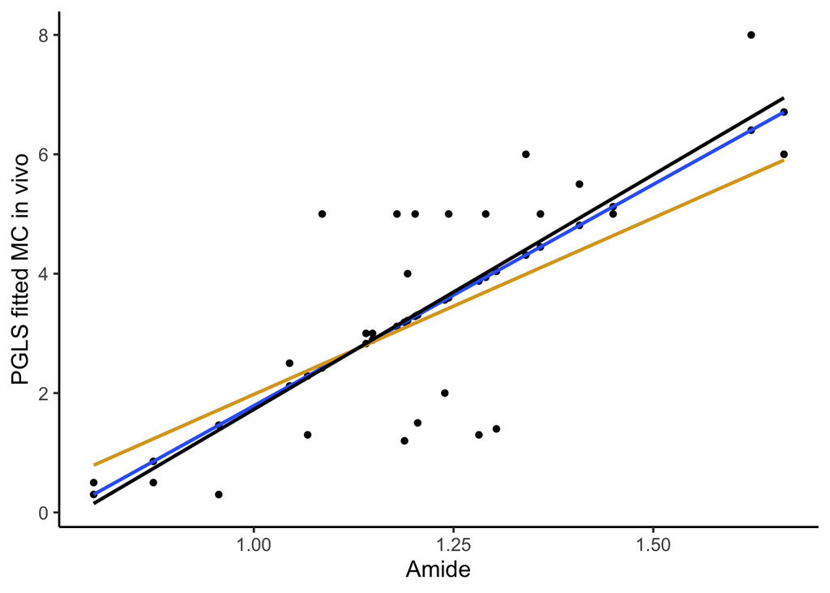

```r
fits <- as.data.frame(pglsModel.pgl.0$fitted)
colnames(fits) <- "fitted"
fits$Amide <-pgls.dat$X.S.N..Amide...MC.in.vivo..normalized.spectral.intensities.
fits$fitted2 <- pglsModel.pgl.1$fitted

ggplot(fits, aes(Amide, fitted))+
  geom_point()+
  geom_smooth(method=lm, se=F)+
  geom_smooth(aes(y=fitted2),method=lm, se=F, color="goldenrod")+
  geom_smooth(data=pgls.dat, aes(x=X.S.N..Amide...MC.in.vivo..normalized.spectral.intensities., y=Literature.MR..mL.O2...1.h...1.g.), method=lm, se=F, color="black")+
  geom_point(data=pgls.dat, aes(x=X.S.N..Amide...MC.in.vivo..normalized.spectral.intensities., y=Literature.MR..mL.O2...1.h...1.g.))+
  theme_classic(base_size = 14)+
  labs(x="Amide", y="PGLS fitted MC in vivo")
```

This plot shows the two PGLS regression lines from the tree they used for their figures, ancestral state reconstruction and, presumably, PGLS. The black line is just uncorrected linear model. The blue line is essentially identical to uncorrected linear regression setting *lamda*= 0 (phylogenetic independence). This is the line supported by model selection. The yellow line is the model forcing a high level of phylo signal ( *lamda* = 1).This line is not supported. *lamda* is estimated at ~ 0.17 by “best” model.

### PGLS using Time tree from timetree.org

```r
# compute weights
w2<-diag(vcv.phylo(tree.tt))

#Pagel correlation structure
#lamda = 1 #pure Brownian motion; high phylo signal
tt.pgl.1 <- gls(Literature.MR..mL.O2...1.h...1.g. ~ X.S.N..Amide...MC.in.vivo..normalized.spectral.intensities., correlation = corPagel(1,  tree.tt, form = ~Taxon.Name, fixed=T),
    data = pgls.dat2, method = "REML")

summary(tt.pgl.1)
```

```
## Generalized least squares fit by REML
##   Model: Literature.MR..mL.O2...1.h...1.g. ~ X.S.N..Amide...MC.in.vivo..normalized.spectral.intensities.
##   Data: pgls.dat2
##       AIC      BIC   logLik
##   96.2564 99.52952 -45.1282
##
## Correlation Structure: corPagel
##  Formula: ~Taxon.Name
##  Parameter estimate(s):
## lambda
##      1
##
## Coefficients:
##                                                                 Value Std.Error
## (Intercept)                                                 -4.332293  2.191044
## X.S.N..Amide...MC.in.vivo..normalized.spectral.intensities.  6.284117  1.468292
##                                                               t-value p-value
## (Intercept)                                                 -1.977274  0.0607
## X.S.N..Amide...MC.in.vivo..normalized.spectral.intensities.  4.279883  0.0003
##
##  Correlation:
##                                                             (Intr)
## X.S.N..Amide...MC.in.vivo..normalized.spectral.intensities. -0.809
##
## Standardized residuals:
##         Min          Q1         Med          Q3         Max
## -0.89979017 -0.42083237  0.07089611  0.47438410  0.91827065
##
## Residual standard error: 2.733929
## Degrees of freedom: 24 total; 22 residual
```

We see that a pure Brownian Motion model with high phylo signal and *Dendrocygna* removed further reduces the slope of the extant calibration from 7.867 to 6.284117 and further increases the intercept from -6.141 to -4.332293

Next we will run a model with a starting value of *lamda* at zero.

```r
#lamda = 0 #Low phylo signal, just plain old regression
tt.pgl.0 <- gls(Literature.MR..mL.O2...1.h...1.g. ~ X.S.N..Amide...MC.in.vivo..normalized.spectral.intensities., correlation = corPagel(0,  tree.tt, form = ~Taxon.Name),
    data = pgls.dat2, method = "REML")

summary(tt.pgl.0)
```

```
## Generalized least squares fit by REML
##   Model: Literature.MR..mL.O2...1.h...1.g. ~ X.S.N..Amide...MC.in.vivo..normalized.spectral.intensities.
##   Data: pgls.dat2
##       AIC      BIC    logLik
##   91.2505 95.61467 -41.62525
##
## Correlation Structure: corPagel
##  Formula: ~Taxon.Name
##  Parameter estimate(s):
##      lambda
## -0.03983225
##
## Coefficients:
##                                                                 Value Std.Error
## (Intercept)                                                 -6.310608  1.889181
## X.S.N..Amide...MC.in.vivo..normalized.spectral.intensities.  7.998161  1.533615
##                                                               t-value p-value
## (Intercept)                                                 -3.340394   0.003
## X.S.N..Amide...MC.in.vivo..normalized.spectral.intensities.  5.215235   0.000
##
##  Correlation:
##                                                             (Intr)
## X.S.N..Amide...MC.in.vivo..normalized.spectral.intensities. -0.99
##
## Standardized residuals:
##        Min         Q1        Med         Q3        Max
## -1.8236587 -0.6750827  0.2029145  0.7226719  1.7645384
##
## Residual standard error: 1.489397
## Degrees of freedom: 24 total; 22 residual
```

```r
anova(tt.pgl.0, tt.pgl.1)
```

```
##          Model df     AIC      BIC    logLik   Test  L.Ratio p-value
## tt.pgl.0     1  4 91.2505 95.61467 -41.62525
## tt.pgl.1     2  3 96.2564 99.52952 -45.12820 1 vs 2 7.005899  0.0081
```

```r
#Indicates low phylo signal; use tt.pgl.1 as correction
```

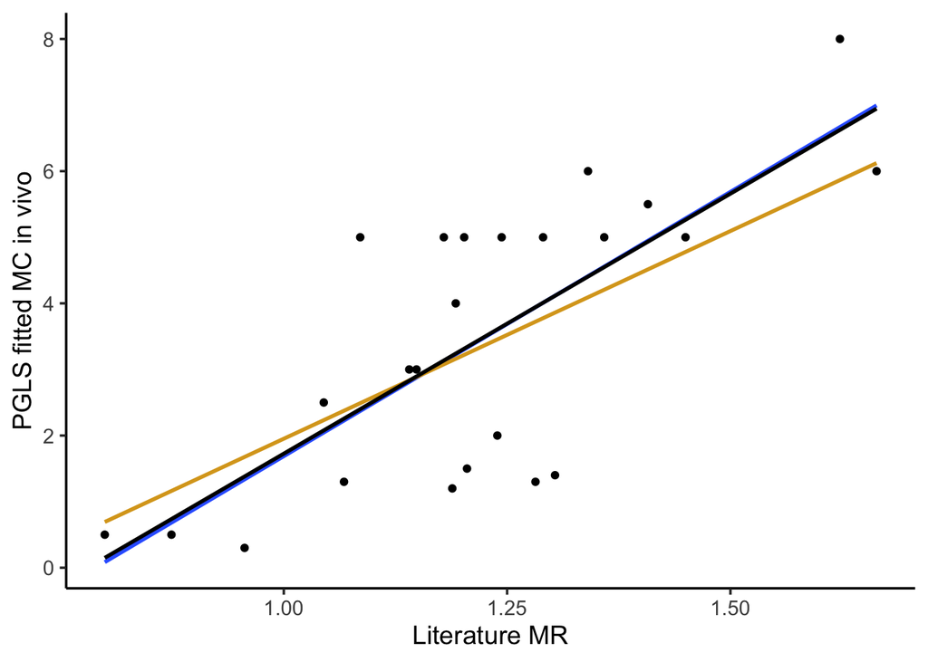

```r
fits <- as.data.frame(tt.pgl.0$fitted)
colnames(fits) <- "fitted"
fits$Amide<-pgls.dat2$X.S.N..Amide...MC.in.vivo..normalized.spectral.intensities.
fits$fitted2 <-(tt.pgl.1$fitted)


ggplot(fits, aes(Amide, fitted))+
  geom_smooth(method=lm, se=F)+
  geom_smooth(aes(y=fitted2), method=lm, se=F, color="goldenrod")+
  geom_smooth(data=pgls.dat2, aes(x=X.S.N..Amide...MC.in.vivo..normalized.spectral.intensities., y=Literature.MR..mL.O2...1.h...1.g.), method=lm, se=F, color="black")+
  geom_point(data=pgls.dat2, aes(x=X.S.N..Amide...MC.in.vivo..normalized.spectral.intensities., y=Literature.MR..mL.O2...1.h...1.g.))+
  theme_classic(base_size = 14)+
  labs(x="Literature MR", y="PGLS fitted MC in vivo")
```

This plot shows the two PGLS regression lines from the timetree pgls. The black line is just regular linear model. The blue line (barely visible) is essentially identical to uncorrected linear regression.This is the line supported by model selection. The yellow line is the model forcing a high level of phylo signal ( *lamda* = 1).This line is not supported. *Lamda* is estimated at ~ 0.

Therefore, we will give them the benefit of the doubt and use the time tree pgls with *Dendrocygna* removed. This flattens slope slightly changing calibration formula from (9.527 * *MC in vivo*) - 8.060 to (7.998161 * *MC in vivo*) - 6.310608 for all extant taxa.

```r
# Add corrected columns for adjusted calcuatedMR and corrected
# We will give them the benefit  of the doubt and use the time tree pgls with Dendrocygna removed. This flattens slope slighlty...

 dat.calib.extant$adj_calc_MR <-(7.998161*dat.calib.extant$X.S.N..Amide...MC.in.vivo..normalized.spectral.intensities.)-6.310608
 dat.calib.extant$adj_corr_MR <-dat.calib.extant$adj_calc_MR +0.9

#This is for fun to see what applying the fossil calibration (since they used extant MRs anyway) to all extant taxa
dat.calib.extant$adj_calc_MR_foss_cab <-(0.3207*dat.calib.extant$X.S.N..Amide...MC.in.vivo..normalized.spectral.intensities.)+0.3371
dat.calib.extant$adj_corr_MR_foss_cab <-dat.calib.extant$adj_calc_MR_foss_cab +0.9
```

# Apply fossil calibration

Unfold to view step-by step process

```r
dat.calib.fossil[31,1]<- dat.calib.fossil[1,1]
dat.calib.fossil[31,8]<- dat.calib.fossil[1,8]
dat.calib.fossil[31,9]<- 2.35


#summary(lm.calib.rm)
#  This is how fossils were calibrated (0.3207*Fossil Amide here)-0.3371
#with added uncertainty add 1.2 to the value calculated above
#use the above equation to produce corrected fossil MR estimates
dat.calib.fossil$adj_calc_MR <- (0.3207*dat.calib.fossil$X.S.N..Amide..normalized.spectral.intensities....MC.in.vivo) +0.3371
dat.calib.fossil$adj_corr_MR <- dat.calib.fossil$adj_calc_MR+ 1.2

dat.calib.fossil$adj_calc_MR_foss_cab <- (0.3207*dat.calib.fossil$X.S.N..Amide..normalized.spectral.intensities....MC.in.vivo) +0.3371
dat.calib.fossil$adj_corr_MR_foss_cab <- dat.calib.fossil$adj_calc_MR_foss_cab + 1.2


#remove the first row Anseriform Bird

dat.calib.fossil.2 <- dat.calib.fossil%>%
  slice(2:31)%>%
  dplyr::select(Taxon, adj_calc_MR, adj_corr_MR, adj_calc_MR_foss_cab, adj_corr_MR_foss_cab) #select only columns needed for plotting

dat.calib.extant.2 <- dat.calib.extant%>%
  #filter(!row_number() %in% c(8))%>%
  dplyr::select(Taxon.Name, adj_calc_MR, adj_corr_MR, adj_calc_MR_foss_cab, adj_corr_MR_foss_cab)%>%#select only columns needed for plotting
  dplyr::rename(Taxon=Taxon.Name)

full.analyses.df <- rbind(dat.calib.fossil.2, dat.calib.extant.2)

body.masses <- dat.lm$Body.mass..g.
full.analyses.df<-full.analyses.df%>%
  left_join(., dat.lm, by="Taxon")
full.analyses.df$Mass.Spec.MR.corr <- (full.analyses.df$Body.mass..g.* full.analyses.df$adj_corr_MR)
full.analyses.df$Log.10.MR.corr <- log10(full.analyses.df$Mass.Spec.MR.corr)

full.analyses.dfMass.Spec.MR.corr.foss.cab <- (full.analyses.df$Body.mass..g.* full.analyses.df$adj_corr_MR_foss_cab)
full.analyses.df$Log.10.MR.corr.foss.cab <- log10(full.analyses.df$Mass.Spec.MR.corr)

#endotherm model where we apply fossil calibration to all data
end.mod.foss.cab <- full.analyses.df%>%
  filter(classification=="endo",
         Age=="Extant")%>%
  lm(Log.10.MR.corr.foss.cab ~Log.10..Body.Mass..g., data=.)

temp_var_endo_foss_cab <- predict(end.mod.foss.cab, interval="prediction")
new_df_endo_foss_cab <- cbind(full.analyses.df%>%
  filter(classification=="endo",
         Age=="Extant"), temp_var_endo_foss_cab)

#endotherm model with separate fossil and extant calibration as above and in Weimann et al. 2022
end.mod2 <- full.analyses.df%>%
  filter(thermy=="endo")%>%
  lm(Log.10.MR.corr ~Log.10..Body.Mass..g., data=.)

newdata <- full.analyses.df%>% dplyr::select(Log.10..Body.Mass..g.)

temp_var_endo_PI <- predict(end.mod2, newdata=newdata, interval="prediction", level=0.95)
temp_var_endo_CI <- predict(end.mod2, newdata=newdata, interval="confidence", level=0.95)

new_df_endo_PI <- cbind(full.analyses.df, temp_var_endo_PI)
new_df_endo_CI <- cbind(full.analyses.df, temp_var_endo_CI)

#other therm model with extant and fossil calibration to generate PI and CI
oth.mod2 <- full.analyses.df%>%
  filter(classification %in%  c("ecto","meso", "oth"),
         Age=="Extant")%>%
  lm(Log.10.MR.corr ~Log.10..Body.Mass..g., data=.)

temp_var_oth_PI <- predict(oth.mod2, newdata=newdata, interval="prediction", level=0.95)
new_df_oth_PI <- cbind(full.analyses.df, temp_var_oth_PI)
```

# Expected MR patterns

Finally, we use John Grady’s conceptual framework to test whether the mass specific MR shows the expected decrease with body mass or is flat consistent with the canceling effects of lifespan and cell metabolic rate.

## Plot mass-specific MR x mass for orginal and recalibrated data:

```
##
## Call:
## lm(formula = log10(adj_corr_MR) ~ Log.10..Body.Mass..g., data = .)
##
## Residuals:
##      Min       1Q   Median       3Q      Max
## -0.26155 -0.06097 -0.03313  0.05789  0.30582
##
## Coefficients:
##                       Estimate Std. Error t value Pr(>|t|)
## (Intercept)            0.67072    0.06165  10.880 2.55e-10 ***
## Log.10..Body.Mass..g. -0.01330    0.01747  -0.761    0.455
## ---
## Signif. codes:  0 '***' 0.001 '**' 0.01 '*' 0.05 '.' 0.1 ' ' 1
##
## Residual standard error: 0.127 on 22 degrees of freedom
## Multiple R-squared:  0.02565,    Adjusted R-squared:  -0.01864
## F-statistic: 0.5792 on 1 and 22 DF,  p-value: 0.4547
```

```
##
## Call:
## lm(formula = log10(adj_corr_MR) ~ Log.10..Body.Mass..g., data = .)
##
## Residuals:
##      Min       1Q   Median       3Q      Max
## -0.41113 -0.06798 -0.00660  0.07986  0.28958
##
## Coefficients:
##                       Estimate Std. Error t value Pr(>|t|)
## (Intercept)            0.37316    0.20532   1.817   0.0942 .
## Log.10..Body.Mass..g.  0.01355    0.06676   0.203   0.8426
## ---
## Signif. codes:  0 '***' 0.001 '**' 0.01 '*' 0.05 '.' 0.1 ' ' 1
##
## Residual standard error: 0.1855 on 12 degrees of freedom
## Multiple R-squared:  0.003419,   Adjusted R-squared:  -0.07963
## F-statistic: 0.04117 on 1 and 12 DF,  p-value: 0.8426
```

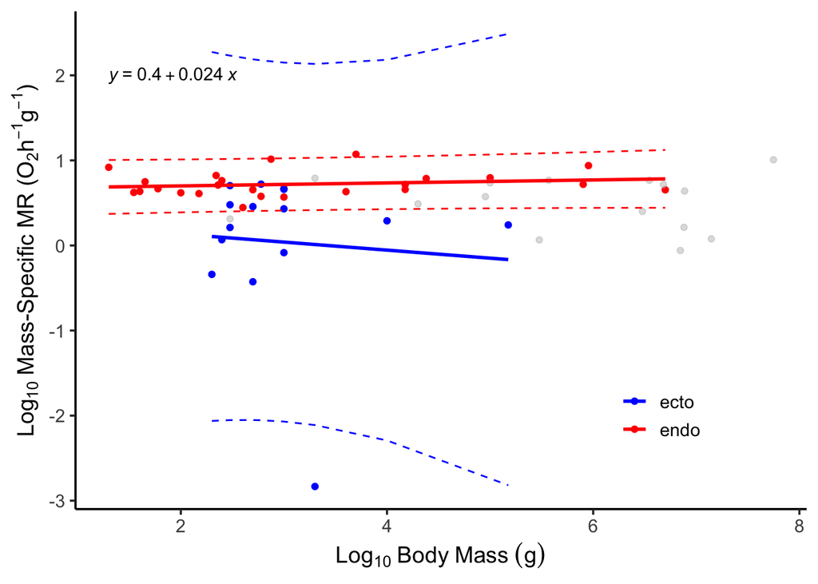

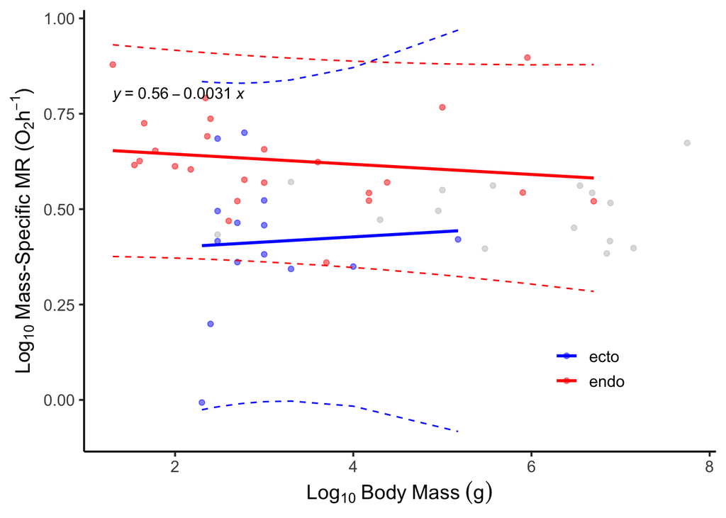

*Left Panel* shows log-log plot of mass-specific MR by body mass for original uncorrected data from Wiemann et al. (2022). *Left Panel* shows same relationship but with re-calibrated data. Red and blue lines are separate regressions for known endotherms and ectotherms respectively. Grey points are unclassified fossil data. Notice uncorrected data has no relationship. Regression equations for combined data are shown. Notice neither original nor corrected data show the expected scaling relationship of -1/4. Both are essentially flat though endotherms and ectotherms are have slightly different relationships when plotted separately.

# Bayesian Predictive Models

## Create response variable

We will code a dummy variable with a 1 for endotherm and a 0 for non-endotherm, standardize predictors, etc…

```r
dat.brms <- full.analyses.df%>%
  mutate(endo=if_else(classification %in% c("endo"), 1, 0),
         log10_adj_corr_MR.z = standardize(log10(adj_corr_MR)),
         log10_mass.z = standardize(Log.10..Body.Mass..g.),
         log10_MR_corr_no_mass_z = standardize(Log.10.MR.corr))
```

### Run a intercept only model with mass-specific MR

```r
#use this to get idea of priors then set your own!!
# priors <-get_prior(endo ~ 1, data = dat.brms%>%filter(Age=="Extant"), family = bernoulli())
#
# int.only <- brm(
#   formula = brms::bf(endo ~ 1),
#   data = dat.brms%>%filter(Age=="Extant"),
#   family = bernoulli(),
#   cores = 4,
#   chains = 4,
#   thin = 10, #chop out transitions?
#   warmup = 5000, #half of iterations
#   iter = 10000,
#   #prior = c(
#   #     prior(normal(0, 10), "Intercept"),
#   #     prior(cauchy(0, 2.5), "sigma")),
#   prior = priors,
#   save_pars = save_pars(all = TRUE), #need this for loo comparison
#   control = list(adapt_delta = 0.97, max_treedepth = 18), #adapt_delta the target average proposal acceptance probability during Stan's adaptation period
#   set.seed(2020)
# )
#
# save(int.only, file=paste(getwd(),"/brms_models/", "int_only.RData", sep="")) # save model

load(file=paste(getwd(),"/brms_models/", "int_only.RData", sep="")) # If loading from pre-saved file and not re-running

#pp_check(int.only, ndraws = 100)
#pp_check(int.only, type = "stat", stat = 'median', ndraws = 2000)
#pp_check(int.only, type = "stat", stat = 'mean', ndraws = 2000)

# trace and density plots
#plot(int.only)
```

### Run an additive model with predictor: log10_adj_corr_MR.z (log 10(standardized adjusted MR from our re-calibrations)

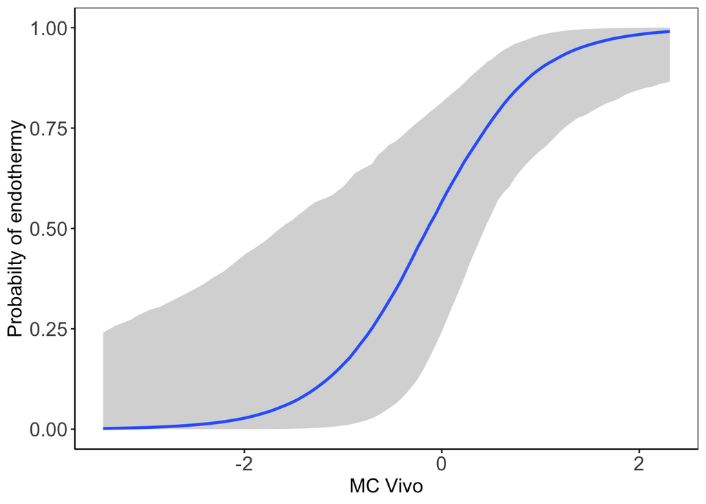

```r
#use this to get idea of priors then set your own!!
# priors <-get_prior(endo ~ log10_adj_corr_MR.z, data = dat.brms%>%filter(Age=="Extant"), family = bernoulli())
# #
# MR.only <- brm(
#   formula = brms::bf(endo ~ log10_adj_corr_MR.z),
#   data = dat.brms%>%filter(Age=="Extant"),
#   family = bernoulli(),
#   cores = 4,
#   chains = 4,
#   thin = 10, #chop out transitions?
#   warmup = 5000, #half of iterations
#   iter = 10000,
#   prior = c(
#        prior(student_t(3, 0, 2.5), "Intercept"),
#        prior(normal(0, 5), "b")),
#   #prior = priors,
#   save_pars = save_pars(all = TRUE), #need this for loo comparison
#   control = list(adapt_delta = 0.97, max_treedepth = 18), #adapt_delta the target average proposal acceptance probability during Stan's adaptation period
#   set.seed(2020)
# )

# save(MR.only, file=paste(getwd(),"/brms_models/", "MR_only.RData", sep="")) # save model

load(paste(getwd(),"/brms_models/", "MR_only.RData", sep="")) # If loading from pre-saved file and not re-running

# summary(MR.only)
#pp_check(MR.only, ndraws = 100)
#pp_check(MR.only, type = "stat", stat = 'median', ndraws = 2000)
#pp_check(MR.only, type = "stat", stat = 'mean', ndraws = 2000)

# trace and density plots
#plot(MR.only)

me <- conditional_effects(MR.only, "log10_adj_corr_MR.z")
p <-plot(me, plot = FALSE)[[1]] +
  scale_color_grey() +
  scale_fill_grey()+
  theme(axis.text.y   = element_text(size=14),
        axis.text.x   = element_text(size=14),
        axis.title.y  = element_text(size=14),
        axis.title.x  = element_text(size=14),
        panel.background = element_blank(),
        panel.grid.major = element_blank(),
        panel.grid.minor = element_blank(),
        axis.line = element_line(colour = "black"),
        panel.border = element_rect(colour = "black", fill=NA, size=0.5))+labs(y="Probabilty of endothermy", x= "MC Vivo")
p
```

If we plot the conditional effect of MC vivo against probability of endothermy. we can see that at lower values of MC vivo the probability of endothermy is low but with substantial uncertainty. Likewise as MC vivo increases the probability of endothermy increases.

### Run an additive model with predictors:

log10_adj_corr_MR.z (log 10(standardized adjusted MR from our re-calibrations); Log.10..Body.Mass..g.z (what a nice name, standardized log10 body mass in grams)

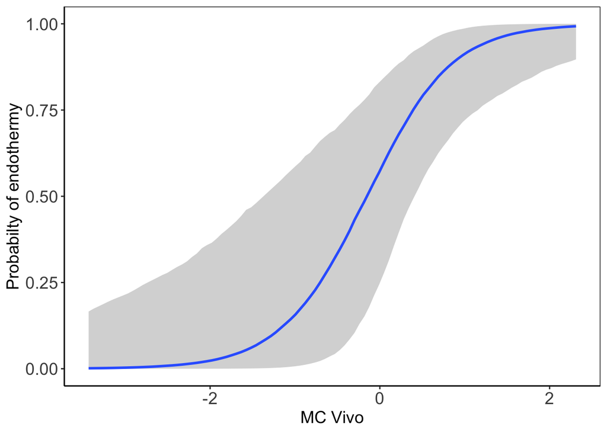

```r
#use this to get idea of priors then set your own!!
# priors <-get_prior(endo ~ log10_adj_corr_MR.z + log10_mass.z, data = dat.brms%>%filter(Age=="Extant"), family = bernoulli(link = "logit"))
#
# MR.mass <- brm(
#   formula = brms::bf(endo ~ log10_adj_corr_MR.z + log10_mass.z ),
#   data = dat.brms%>%filter(Age=="Extant"),
#   family = bernoulli(link = "logit"),
#   cores = 4,
#   chains = 4,
#   thin = 10, #chop out transitions?
#   warmup = 5000, #half of iterations
#   iter = 10000,
#   prior = c(
#       prior(student_t(3, 0, 2.5), "Intercept"),
#       prior(normal(0, 5), "b")),
#   #prior = priors,
#   save_pars = save_pars(all = TRUE), #need this for loo comparison
#   control = list(adapt_delta = 0.97, max_treedepth = 18), #adapt_delta the target average proposal acceptance probability during Stan's adaptation period
#   set.seed(2020)
# )
#
# save(MR.mass, file=paste(getwd(),"/brms_models/", "MR_mass.RData", sep="")) # save model

load(paste(getwd(),"/brms_models/", "MR_mass.RData", sep="")) # If loading from pre-saved file and not re-running

#summary(MR.mass)
#pp_check(MR.mass, ndraws = 100)
#pp_check(MR.mass, type = "stat", stat = 'median', ndraws = 2000)
#pp_check(MR.mass, type = "stat", stat = 'mean', ndraws = 2000)

# trace and density plots
#plot(MR.mass)


me <- conditional_effects(MR.mass, "log10_adj_corr_MR.z")
p <-plot(me, plot = FALSE)[[1]] +
  scale_color_grey() +
  scale_fill_grey()+
  theme(axis.text.y   = element_text(size=14),
        axis.text.x   = element_text(size=14),
        axis.title.y  = element_text(size=14),
        axis.title.x  = element_text(size=14),
        panel.background = element_blank(),
        panel.grid.major = element_blank(),
        panel.grid.minor = element_blank(),
        axis.line = element_line(colour = "black"),
        panel.border = element_rect(colour = "black", fill=NA, size=0.5))+labs(y="Probabilty of endothermy", x= "MC Vivo")
p
```

```r
#This is just cleaner theme
#plot_cap(MR.mass, condition = "log10_adj_corr_MR.z")
```

Models look no different with respect to conditional effect of MC vivo. We will do model selection by LOOIC below.